# Bellabeat case study

About the company

Urška Sršen and Sando Mur founded Bellabeat, a high-tech company that manufactures health-focused smart products. Sršen used her background as an artist to develop beautifully designed technology that informs and inspires women around the world. Collecting data on activity, sleep, stress, and reproductive health has allowed Bellabeat to empower women with knowledge about their own health and habits. Since it was founded in 2013, Bellabeat has grown rapidly and quickly positioned itself as a tech-driven wellness company for women.

**ASK**

Business task: Analyze a smart device fitness data (non-bellabeat product) to help bellabeat unlock new growth opportunities for the company.

Key stakeholders

Urška Sršen, Sando Mur, Bellabeat marketing analysis team.

**PREPARE**

**PROCESS**

For this analysis I’ll be using R. I am using this tool because R can clean, analyze, and visualize the data.

Load the needed packages.

```r
library(tidyverse)
library(lubridate)
```

```r
library(dplyr)
library(ggplot2)
library(tidyr)
library(readr)
```

Import the datasets.

```r
activity <- read_csv("dailyActivity_merged.csv")
sleep <- read_csv("sleepDay_merged.csv")
weight <- read_csv("weightLogInfo_merged.csv")
head(activity)
```

| Id | ActivityDate | TotalSteps | TotalDistance | TrackerDistance | LoggedActivitiesDistance | VeryActiveDistance | ModeratelyActiveDistance | LightActiveDistance | SedentaryActiveDistance | VeryActiveMinutes | FairlyActiveMinutes | LightlyActiveMinutes | SedentaryMinutes | Calories |
| --- | --- | --- | --- | --- | --- | --- | --- | --- | --- | --- | --- | --- | --- | --- |
| 1503960366 | 4/12/2016 | 13162 | 8.50 | 8.50 | 0 | 1.88 | 0.55 | 6.06 | 0 | 25 | 13 | 328 | 728 | 1985 |
| 1503960366 | 4/13/2016 | 10735 | 6.97 | 6.97 | 0 | 1.57 | 0.69 | 4.71 | 0 | 21 | 19 | 217 | 776 | 1797 |
| 1503960366 | 4/14/2016 | 10460 | 6.74 | 6.74 | 0 | 2.44 | 0.40 | 3.91 | 0 | 30 | 11 | 181 | 1218 | 1776 |
| 1503960366 | 4/15/2016 | 9762 | 6.28 | 6.28 | 0 | 2.14 | 1.26 | 2.83 | 0 | 29 | 34 | 209 | 726 | 1745 |
| 1503960366 | 4/16/2016 | 12669 | 8.16 | 8.16 | 0 | 2.71 | 0.41 | 5.04 | 0 | 36 | 10 | 221 | 773 | 1863 |
| 1503960366 | 4/17/2016 | 9705 | 6.48 | 6.48 | 0 | 3.19 | 0.78 | 2.51 | 0 | 38 | 20 | 164 | 539 | 1728 |

```r
activity <- activity %>%
  rename (Date = ActivityDate) %>%
  mutate (Date = as.Date(Date, format = "%m/%d/%y"))
sleep <- sleep %>%
  rename (Date = SleepDay) %>%
  mutate (Date = as.Date(Date, format = "%m/%d/%y"))
weight <- weight %>%
  mutate (Date = as.Date(Date, format = "%m/%d/%y"))
```

```r
n_distinct(activity$Id)
```

```
## [1] 33
```

```r
n_distinct(sleep$Id)
```

```
## [1] 24
```

```r
n_distinct(weight$Id)
```

```
## [1] 8
```

```r
merged_table <- merge(merge(activity, sleep, by = c('Id', 'Date'), all = TRUE), weight, by = c('Id', 'Date'), all = TRUE)
```

```r
head(merged_table)
```

|  | Id | Date | TotalSteps | TotalDistance | TrackerDistance | LoggedActivitiesDistance | VeryActiveDistance | ModeratelyActiveDistance | LightActiveDistance | SedentaryActiveDistance | VeryActiveMinutes | FairlyActiveMinutes | LightlyActiveMinutes | SedentaryMinutes | Calories | TotalSleepRecords | TotalMinutesAsleep | TotalTimeInBed | WeightKg | WeightPounds | Fat | BMI | IsManualReport | LogId |
| --- | --- | --- | --- | --- | --- | --- | --- | --- | --- | --- | --- | --- | --- | --- | --- | --- | --- | --- | --- | --- | --- | --- | --- | --- |
| 1 | 1503960366 | 2020-04-12 | 13162 | 8.50 | 8.50 | 0 | 1.88 | 0.55 | 6.06 | 0 | 25 | 13 | 328 | 728 | 1985 | 1 | 327 | 346 | NA | NA | NA | NA | NA | NA |
| 2 | 1503960366 | 2020-04-13 | 10735 | 6.97 | 6.97 | 0 | 1.57 | 0.69 | 4.71 | 0 | 21 | 19 | 217 | 776 | 1797 | 2 | 384 | 407 | NA | NA | NA | NA | NA | NA |
| 3 | 1503960366 | 2020-04-14 | 10460 | 6.74 | 6.74 | 0 | 2.44 | 0.40 | 3.91 | 0 | 30 | 11 | 181 | 1218 | 1776 | NA | NA | NA | NA | NA | NA | NA | NA | NA |
| 4 | 1503960366 | 2020-04-15 | 9762 | 6.28 | 6.28 | 0 | 2.14 | 1.26 | 2.83 | 0 | 29 | 34 | 209 | 726 | 1745 | 1 | 412 | 442 | NA | NA | NA | NA | NA | NA |
| 5 | 1503960366 | 2020-04-16 | 12669 | 8.16 | 8.16 | 0 | 2.71 | 0.41 | 5.04 | 0 | 36 | 10 | 221 | 773 | 1863 | 2 | 340 | 367 | NA | NA | NA | NA | NA | NA |
| 6 | 1503960366 | 2020-04-17 | 9705 | 6.48 | 6.48 | 0 | 3.19 | 0.78 | 2.51 | 0 | 38 | 20 | 164 | 539 | 1728 | 1 | 700 | 712 | NA | NA | NA | NA | NA | NA |

```r
summary(merged_table)
```

```
##        Id                 Date              TotalSteps    TotalDistance
##  Min.   :1.504e+09   Min.   :2020-04-12   Min.   :    0   Min.   : 0.000
##  1st Qu.:2.320e+09   1st Qu.:2020-04-19   1st Qu.: 3795   1st Qu.: 2.620
##  Median :4.445e+09   Median :2020-04-26   Median : 7439   Median : 5.260
##  Mean   :4.858e+09   Mean   :2020-04-26   Mean   : 7652   Mean   : 5.503
##  3rd Qu.:6.962e+09   3rd Qu.:2020-05-04   3rd Qu.:10734   3rd Qu.: 7.720
##  Max.   :8.878e+09   Max.   :2020-05-12   Max.   :36019   Max.   :28.030
##
##  TrackerDistance  LoggedActivitiesDistance VeryActiveDistance
##  Min.   : 0.000   Min.   :0.000            Min.   : 0.000
##  1st Qu.: 2.620   1st Qu.:0.000            1st Qu.: 0.000
##  Median : 5.260   Median :0.000            Median : 0.220
##  Mean   : 5.489   Mean   :0.110            Mean   : 1.504
##  3rd Qu.: 7.715   3rd Qu.:0.000            3rd Qu.: 2.065
##  Max.   :28.030   Max.   :4.942            Max.   :21.920
##
##  ModeratelyActiveDistance LightActiveDistance SedentaryActiveDistance
##  Min.   :0.0000           Min.   : 0.000      Min.   :0.000000
##  1st Qu.:0.0000           1st Qu.: 1.950      1st Qu.:0.000000
##  Median :0.2400           Median : 3.380      Median :0.000000
##  Mean   :0.5709           Mean   : 3.349      Mean   :0.001601
##  3rd Qu.:0.8050           3rd Qu.: 4.790      3rd Qu.:0.000000
##  Max.   :6.4800           Max.   :10.710      Max.   :0.110000
##
##  VeryActiveMinutes FairlyActiveMinutes LightlyActiveMinutes SedentaryMinutes
##  Min.   :  0.00    Min.   :  0.00      Min.   :  0          Min.   :   0.0
##  1st Qu.:  0.00    1st Qu.:  0.00      1st Qu.:127          1st Qu.: 729.0
##  Median :  4.00    Median :  7.00      Median :199          Median :1057.0
##  Mean   : 21.24    Mean   : 13.63      Mean   :193          Mean   : 990.4
##  3rd Qu.: 32.00    3rd Qu.: 19.00      3rd Qu.:264          3rd Qu.:1229.0
##  Max.   :210.00    Max.   :143.00      Max.   :518          Max.   :1440.0
##
##     Calories    TotalSleepRecords TotalMinutesAsleep TotalTimeInBed
##  Min.   :   0   Min.   :1.000     Min.   : 58.0      Min.   : 61.0
##  1st Qu.:1830   1st Qu.:1.000     1st Qu.:361.0      1st Qu.:403.0
##  Median :2140   Median :1.000     Median :433.0      Median :463.0
##  Mean   :2308   Mean   :1.119     Mean   :419.5      Mean   :458.6
##  3rd Qu.:2796   3rd Qu.:1.000     3rd Qu.:490.0      3rd Qu.:526.0
##  Max.   :4900   Max.   :3.000     Max.   :796.0      Max.   :961.0
##                 NA's   :530       NA's   :530        NA's   :530
##     WeightKg       WeightPounds        Fat             BMI
##  Min.   : 52.60   Min.   :116.0   Min.   :22.00   Min.   :21.45
##  1st Qu.: 61.40   1st Qu.:135.4   1st Qu.:22.75   1st Qu.:23.96
##  Median : 62.50   Median :137.8   Median :23.50   Median :24.39
##  Mean   : 72.04   Mean   :158.8   Mean   :23.50   Mean   :25.19
##  3rd Qu.: 85.05   3rd Qu.:187.5   3rd Qu.:24.25   3rd Qu.:25.56
##  Max.   :133.50   Max.   :294.3   Max.   :25.00   Max.   :47.54
##  NA's   :876      NA's   :876     NA's   :941     NA's   :876
##  IsManualReport      LogId
##  Mode :logical   Min.   :1.460e+12
##  FALSE:26        1st Qu.:1.461e+12
##  TRUE :41        Median :1.462e+12
##  NA's :876       Mean   :1.462e+12
##                  3rd Qu.:1.462e+12
##                  Max.   :1.463e+12
##                  NA's   :876
```

**SHARE**

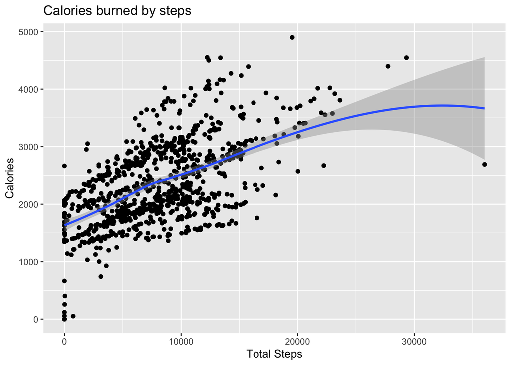

```r
ggplot(data = merged_table, aes(x = TotalSteps, y = Calories)) +
  geom_point() +
  geom_smooth() +
  labs(title = 'Calories burned by steps', y = 'Calories', x = 'Total Steps')
```

There’s a positive correlation between number of steps and calories burnt, which makes sense because the more active one is, the more calorie is being burnt.

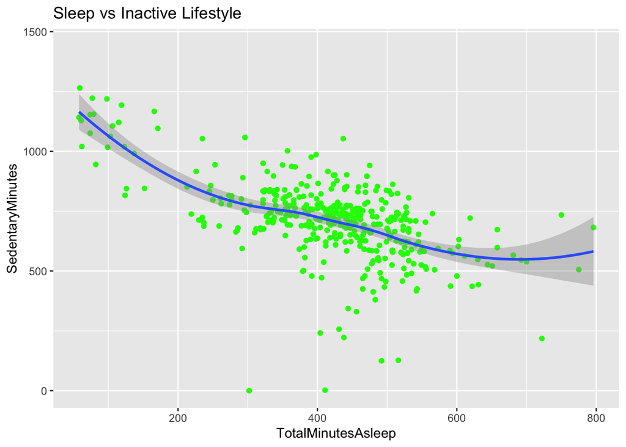

```r
ggplot(data = merged_table, aes(x=TotalMinutesAsleep, y=SedentaryMinutes)) +
  geom_point(color='green') + geom_smooth() +
  labs(title="Sleep vs Inactive Lifestyle")
```

The data here shows that those with a sedentary lifestyle spent less time asleep. There could be several factors affecting sleep cycle but it’s a point worth noting.

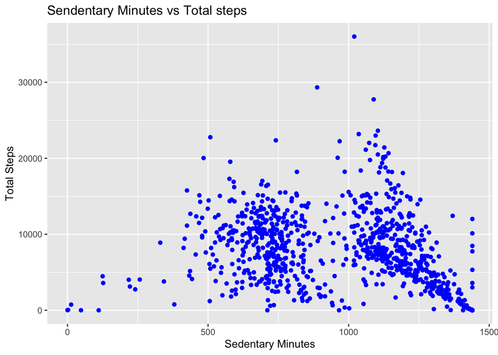

```r
ggplot(data = merged_table, aes(x = SedentaryMinutes, y = TotalSteps)) +
  geom_point(color='blue') +
  labs(title = 'Sendentary Minutes vs Total steps', x = 'Sedentary Minutes', y ='Total Steps')
```

**ACT**

After analyzing Fitbit Fitness Tracker Data , here are a few insights which can be helpful to bellabeat in unlocking new growth opportunities.

*From the reported data, only 8 users reported their weight, bellabeat could develop a scale that helps track weight progress. (Weight gain or weight loss progress over time.)

*Develop app notifications to help alert users when they’re not getting enough steps per day. According to the CDC, most adults should aim for 10,000 steps day. Sending out notifications throughout the day would help users achieve that goal.

*Offer incentives such as (a fraction off the monthly subscription plan) to more active users to help reduce the sedentary time.